# R Notebook

# Machine Learning with Burlington Housing Data

The city of Burlington in Vermont keeps an open dataset for anyone to explore. In this case the goal is to add sale prices for those that do not have it ith machine learning and then decided where I want to explore the data further.

```r
rm(list=ls())
library(ggplot2) # visualization
library(scales) # visualization
library(dplyr) # data manipulation
library(mice) # imputation
library(randomForest) # classification algorithm
library(flexdashboard)
```

Verify the Structure of the dataframe

```r
wholedf <- read.csv("C:/Users/kefor/Desktop/RLearning/City_of_Burlington_Property_Details.csv", header = TRUE)
dim(wholedf)
```

```
[1] 10832    38
```

# Data Structure

First it makes sense to take a look at the structure of the data and see what kind of variables it includes.

```r
str(wholedf)
```

```
'data.frame':   10832 obs. of  38 variables:
 $ AccountNumber        : int  7502 10680 9512 7960 9255 9632 1697 6995 3143 3317 ...
 $ ParcelID             : Factor w/ 10832 levels "002-2-002-000",..: 7754 4431 9796 8239 9541 9922 1754 7218 3238 3409 ...
 $ SpanNumber           : Factor w/ 10828 levels "114-035-10001",..: 7308 10376 9253 7757 8998 9372 1675 6841 3099 3269 ...
 $ StreetNumber         : Factor w/ 946 levels "","0","1","10",..: 387 737 681 421 681 2 264 66 2 102 ...
 $ AlternateNumber      : Factor w/ 362 levels "","1/2","10",..: 1 1 1 1 1 1 1 1 1 1 ...
 $ StreetName           : Factor w/ 369 levels "ADAMS CT","ADAMS ST",..: 85 351 295 308 66 47 338 26 12 185 ...
 $ Unit                 : Factor w/ 603 levels "","Unit 09","Unit 1",..: 1 1 1 1 1 1 1 1 1 1 ...
 $ CuO1LastName         : Factor w/ 6224 levels "","10 DANS COURT BURLINGTON LLC",..: 1262 1906 1268 1173 867 1268 4189 5376 4314 2333 ...
 $ CuO1FirstName        : Factor w/ 4797 levels "","(LESSOR)",..: 3467 1036 1 1 3813 1 4335 4348 1 4291 ...
 $ CuO2LastName         : Factor w/ 3660 levels "","125 BANK STREET EBT, LLC",..: 2518 1022 1 1 1 1 2518 1 1 1 ...
 $ CuO2FirstName        : Factor w/ 3373 levels "","& MORRISSEY DEVELOPMENT",..: 2497 2921 1 1 1 1 2497 1 1 1 ...
 $ CuO3LastName         : Factor w/ 485 levels "","127-129 BANK STREET TAS LLC",..: 324 324 1 1 1 1 324 1 1 1 ...
 $ CuO3FirstName        : Factor w/ 422 levels "","(LESSEE)",..: 306 306 1 1 1 1 306 1 1 1 ...
 $ LandUse              : Factor w/ 27 levels "2 Family","3 Family",..: 12 25 12 11 1 12 25 6 21 25 ...
```

[output cut: 24 more lines]

## Null Values

See how many Null values are in the dataset and if anything needs to be filled in.

```r
colSums(sapply(wholedf, is.na))
```

```
        AccountNumber              ParcelID            SpanNumber          StreetNumber       AlternateNumber
                    0                     0                     0                     0                     0
           StreetName                  Unit          CuO1LastName         CuO1FirstName          CuO2LastName
                    0                     0                     0                     0                     0
        CuO2FirstName          CuO3LastName         CuO3FirstName               LandUse          CurrentAcres
                    0                     0                     0                     0                     0
       TotalGrossArea          FinishedArea          CurrentValue      CurrentLandValue CurrentYardItemsValue
                    0                     0                     0                     0                     0
 CurrentBuildingValue          BuildingType              HeatFuel              HeatType                 Grade
                    0                     0                     0                     0                     0
              YearBlt              SaleDate             SalePrice        LegalReference       GrantorLastName
                    0                     0                     0                     0                     0
           NumofRooms         NumofBedrooms                 Baths            NumofUnits            ZoningCode
                    0                     0                     0                     0                     0
           Foundation          Depreciation   PropertyCenterPoint
                    0                     0                     0
```

## Residential

Cut the data down to just include certain subsets which are just residential properties

```r
wholedf <- subset(wholedf, LandUse == "Single Family" | LandUse == "2 Family" | LandUse == "3 Family" | LandUse == "4 Family" | LandUse == "Apartments 5+Units" | LandUse == "Condo")
```

## Remove Features

Some of the data in this dataframe is not going to be useful in figuring out the saleprice. For those we are going to remove what we don’t need. Dim allows you to verify that the number of columns has dropped

```r
(wholedf <- wholedf[,c(1,2,4,6,8,9,14,15,16,17,18,19,20,21,22,23,24,25,26,27,28,31,32,33,34,35,36,37,38)])
```

[output not shown]

[output cut: 990 more lines]

```r
dim(wholedf)
```

```
[1] 7192   29
```

## Remove SalePrice Outliers

For some of the SalePrice values there are zeros, which in this case refers to missing data. A quick function replaces zeros with “NA” so those values will be automatically discarded when plotted and allow us to seperate it later when it come to splitting it into a training and a testing dataset.

```r
summary(wholedf$SalePrice)
```

```
    Min.  1st Qu.   Median     Mean  3rd Qu.     Max.
       0        0        0   135800   240000 14400000
```

```r
wholedf$SalePrice[1:30]
```

```
 [1]      0      0      0      0      0      0      0      0      0      0      0      0 250000 925000 290000      0 204000
[18] 222680 229000 271000      0      0      0      0      0      0 257000 727000 230000 500000
```

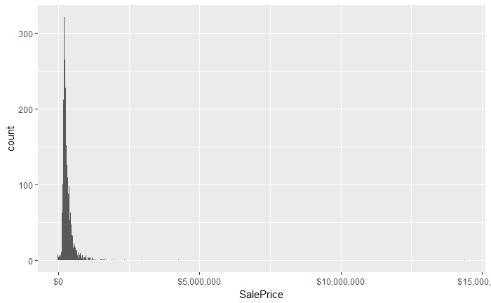

```r
wholedf$SalePrice[wholedf$SalePrice == 0] <- NA
require(scales)
qplot(SalePrice, data=wholedf, geom="histogram",bins=800) +
  scale_x_continuous(labels = dollar)
```

## Sale Price Boundries

Again outliers are a problem so removing the upper edge is useful in our analysis. Perhaps after running this whole thing I may end up going back to cut out more than 2 Family houses to get a better predictive model for what is interesting to me.

```r
#wholedf <- subset(wholedf, wholedf$SalePrice < 1000000 | is.na(wholedf$SalePrice) )
```

## Feature Engineering

Time to make some new features that will be useful in determing the sale price

```r
# Create a new variable
wholedf$PercentFinished <- wholedf$FinishedArea / wholedf$TotalGrossArea
wholedf$PercentBuildingtoTotal <- wholedf$CurrentBuildingValue / wholedf$CurrentValue
```

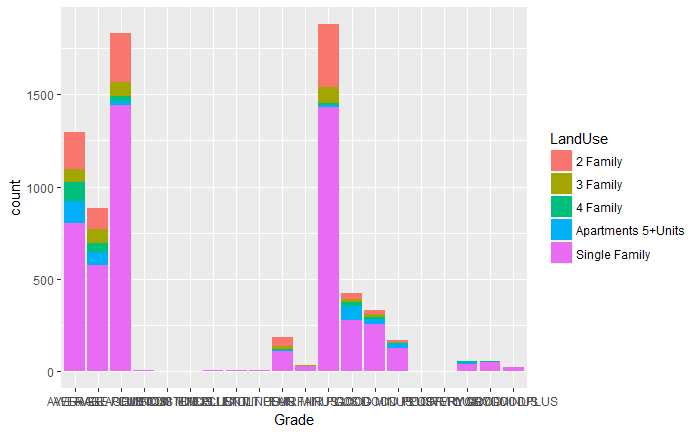

```r
ggplot(wholedf, aes(Grade, fill = LandUse)) +
  geom_bar()
```

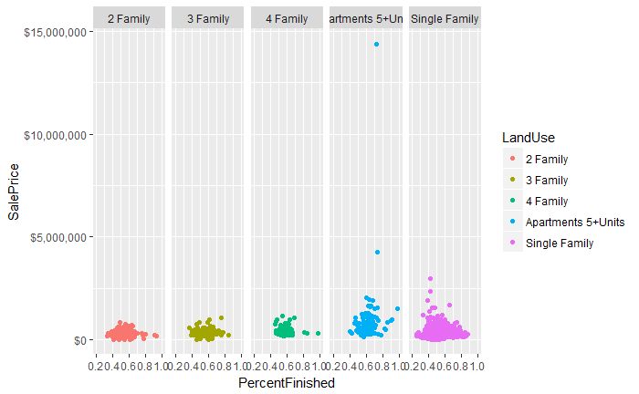

```r
ggplot(wholedf, aes(PercentFinished, SalePrice, colour = LandUse)) +
  geom_point() +
  scale_x_continuous(labels = comma) +
  scale_y_continuous(labels = dollar) +
  facet_grid(.~LandUse)
```

## Create Train/Test Datasets

Split the dataset by if there is a price in SalePrice or not

```r
train <- subset(wholedf, wholedf$SalePrice > 0 )
test <- subset(wholedf, is.na(wholedf$SalePrice) )
```

```r
# Set a random seed
set.seed(500)
# Build the model (note: not all possible variables are used)
rf_model <- randomForest(factor(SalePrice) ~ CurrentAcres + TotalGrossArea + FinishedArea + PercentFinished + NumofRooms + NumofBedrooms + Depreciation, data = train)
```

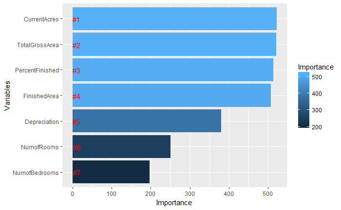

```r
# Get importance
importance    <- importance(rf_model)
varImportance <- data.frame(Variables = row.names(importance),
                            Importance = round(importance[ ,'MeanDecreaseGini'],2))
# Create a rank variable based on importance
rankImportance <- varImportance %>%
  mutate(Rank = paste0('#',dense_rank(desc(Importance))))
# Use ggplot2 to visualize the relative importance of variables
ggplot(rankImportance, aes(x = reorder(Variables, Importance),
    y = Importance, fill = Importance)) +
  geom_bar(stat='identity') +
  geom_text(aes(x = Variables, y = 0.5, label = Rank),
    hjust=0, vjust=0.55, size = 4, colour = 'red') +
  labs(x = 'Variables') +
  coord_flip()
```

```r
# Predict using the test set
prediction <- predict(rf_model, test)
# Save the solution to a dataframe with two columns: PassengerId and Survived (prediction)
solution <- data.frame(ParcelID = test$ParcelID, SalePrice = prediction)
```

```
Error in data.frame(ParcelID = test$ParcelID, SalePrice = prediction) :
  row names contain missing values
```